# Problem Set 5

Due date: 23 October

Please upload your completed assignment to the ELMs course site (under the assignments menu) and to your class Github repository. You need to upload both your Quarto document (with R code, as needed) and its rendered output (either as a PDF or HTML file).

**Total points: 25**

```r
library(scales)
```

## Question 1

*Total points: 6*

Use the data in the table below to answer the following questions.

Voting by Age in 2000

| Age group | Non-voters | Voters | Total |
| --- | --- | --- | --- |
| 18-24 | 70 | 50 | 120 |
| 25-30 | 40 | 50 | 90 |
| 31 and up | 220 | 570 | 790 |
| TOTAL | 330 | 670 | 1000 |

### Part A

*Points: 2*

**Note**

2/2

What is the probability of being 25-30 or a non-voter?

```r
((90/1000)+(330/1000))-(40/1000)
```

```
[1] 0.38
```

**Answer**: 0.38

### Part B

*Points: 4*

**Note**

1/4

Assuming a normal distribution, report the 95% confidence intervals for the percentage of 18-to-24-year-olds who did not vote, and then the percentage of 25-to-30-year-olds who did not vote.

```r
p_hat_1824 <- (70/120)
p_hat_1824
```

```
[1] 0.5833333
```

```r
se_1824 <- sqrt(((p_hat_1824 * (1 - p_hat_1824)) / 120))
se_1824
```

```
[1] 0.04500514
```

```r
lower_1824 <- p_hat_1824 - 1.96 * se_1824
lower_1824
```

```
[1] 0.4951233
```

```r
upper_1824 <- p_hat_1824 + 1.96 * se_1824
upper_1824
```

```
[1] 0.6715434
```

**Answer**: The confidence intervals for 18-to-24 year olds is **49.51%** and **67.15%**

```r
p_hat_2530 <- (40/90)
p_hat_2530
```

```
[1] 0.4444444
```

```r
se_2530 <- sqrt(((p_hat_2530 * (1 - p_hat_2530)) / 90))
se_2530
```

```
[1] 0.05237828
```

```r
lower_2530 <- p_hat_2530 - 1.96 * se_2530
lower_2530
```

```
[1] 0.341783
```

```r
upper_2530 <- p_hat_2530 + 1.96 * se_2530
upper_2530
```

```
[1] 0.5471059
```

**Answer**: The confidence intervals for 25-to-30-year-olds is **34.18%** and **54.71%**

**Tip**

The probability that an individual is 18-to-24 and a non-voter is not conditional. Therefore, you look at the proportion of the whole population who meet those criteria.

$$\hat{p} = Pr(18\ to\ 24 \& NV) = \frac{70}{1000} = 0.07$$

And:

$$n = 1000$$

Therefore:

$$SE(\hat{p}) = \sqrt{\frac{0.07 * 0.93}{1000}} = 0.008068457$$

The 95% confidence interval can be found:

$$\hat{p} \pm 1.96*SE(\hat{p})$$

Therefore, the 95% confidence interval for the percentage of 18-to-24-year-olds who did not vote is 5.42% to 8.58%.

Using the same method, the 95% confidence intervals for the percentage of 25-to-30-year-olds who did not vote is 2.79% to 5.21%.

## Question 2

*Total points:* *7*

Assume that the standard deviation for the population distribution of a state in which you want to conduct a poll is 200.

### Part A

*Points: 3*

**Note**

3/3

Calculate the spread of the sampling distribution for each of the following sample sizes: 1, 4, 25, 100, 250, 1000, 5,000, and 10,000.

```r
(200/sqrt(1))
```

```
[1] 200
```

```r
(200/sqrt(4))
```

```
[1] 100
```

```r
(200/sqrt(25))
```

```
[1] 40
```

```r
(200/sqrt(100))
```

```
[1] 20
```

```r
(200/sqrt(250))
```

```
[1] 12.64911
```

```r
(200/sqrt(1000))
```

```
[1] 6.324555
```

```r
(200/sqrt(5000))
```

```
[1] 2.828427
```

```r
(200/sqrt(10000))
```

```
[1] 2
```

**Answer**:  
1 = 200  
4 = 100  
25 = 40  
100 = 20  
250 = 12.65  
1000 = 6.32  
5000 = 2.83  
10000 = 2

### Part B

*Points: 1*

**Note**

0.5/1

Describe specifically how the variability of the sampling distribution changes as the sample size varies. Considering the expense of running a poll, which sample size do you think is most optimal if conducting the poll?  
**Answer**: 1000 offers a tight spread. Going past 1000 would only provide extremely diminished returns.

**Note**

Missing: Describe specifically how the variability of the sampling distribution changes as the sample size varies.

### Part C

*Points: 3*

**Note**

2.5/3

Display your results graphically (using R) with the sample size on the x-axis and the standard error (of the sampling distribution) on the y-axis.

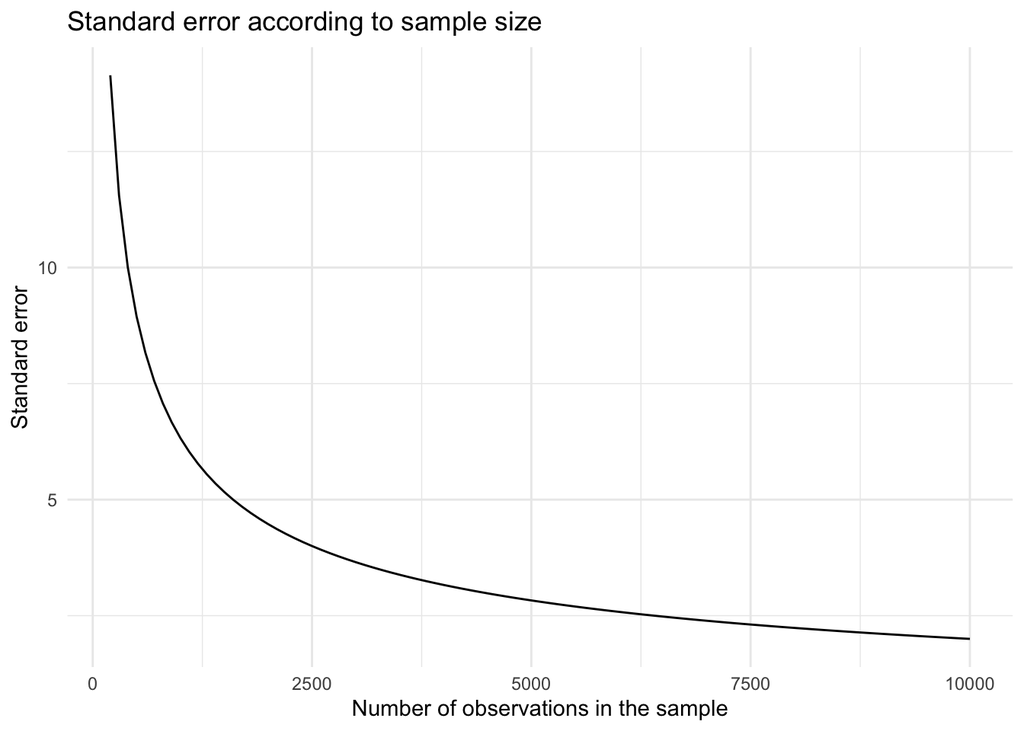

```r
library(ggplot2)
library(tidyverse)
tibble(sample_size = seq(from = 200, to = 10000, by = 100)) |>
  rowwise() |>
  mutate(se = 200/sqrt(sample_size)) |>
  ggplot(aes(x = sample_size, y = se)) +
  geom_line() +
  theme_minimal() +
  labs(title = "Standard error according to sample size",
      x = "Number of observations in the sample",
      y = "Standard error")
```

**Note**

This is good! But the question asks you to display *your results.*

## Question 3

*Points: 4*

**Note**

4/4

```r
print(paste(
  sqrt(( 900 * 4.5^2 ) / ( 1.96^2 ))))
```

```
[1] "68.8775510204082"
```

The z-score for a confidence interval of 90% is approximately 1.645. Given that, the equation to solve for the new m is as follows:

```r
print(paste(
  (1.645 * 68.87755) / sqrt(900)))
```

```
[1] "3.77678565833333"
```

The margin of error for a 90% confidence interval is approximately **3.78**.

## Question 4

*Points: 4*

**Note**

4/4

Assume that, in State A, the mean income in the population is $20,000 with a standard deviation of $2,000. If you took an SRS of 900 individuals from that population, what is the probability that you would get a sample mean income of $20,200 or greater? What would be the probability if the sample size was only 25?

**Note**

Assume a normal distribution for both questions.

**Answer**:  
First, we have to calculate the standard error. We can use the SE for both survey sample sizes to determine their respective Z scores. This is done through the following equation:  
`Z = x̄ - µ / σ`  
Since these surveys are assumed to be distributed Normally, we can use these Z-scores to determine probability.

```r
s_900 <- (2000/sqrt(900))

z_900 <- ((20200 - 20000)/s_900)

print(z_900)
```

```
[1] 3
```

```r
s_25 <- (2000/sqrt(25))

z_25 <- ((20200 - 20000)/s_25)

print(z_25)
```

```
[1] 0.5
```

P(Z ≥ 3.0) = 0.00135  
The probability that you would get a sample mean income of $20,200 or greater in a SRS of 900 is 0.00135.  
P(Z ≥ 0.5) = 0.30854  
The probability that you would get a sample mean income of $20,200 or greater in a SRS of 25 is 0.30854.

## Question 5

*Points: 4*

**Note**

1/4

Assume that a coin is fair. If I flip a coin 500 times, what is a 95% confidence interval for the range of the count of heads that I will get? What if I flip the coin 5,000 times? What about 50,000 times?

**Answer**:  
First, we need to find the standard error for these different counts using the following equation:  
`se(p̂) = √((p (1 - p)/n)`

Since these coins are assumed to be fair, the probability of either outcome is 0.5. Therefore, p = 0.5. Once these standard errors are accounted for, the following equation can be used to determine the range of the count of heads within a 95% confidence interval:  
`p̂ ± 1.96 * se(p̂)`

```r
se_500 <- sqrt((0.5 * 0.5)/500)

upper_500 <- (500 + 1.96*se_500)
lower_500 <- (500 - 1.96*se_500)

print(paste("The range of the count of heads within a 95% confidence interval for 500 coin flips is between", upper_500, "and", lower_500))
```

```
[1] "The range of the count of heads within a 95% confidence interval for 500 coin flips is between 500.043826932359 and 499.956173067641"
```

```r
se_5k <- sqrt((0.5 * 0.5)/5000)

upper_5k <- (5000 + 1.96*se_5k)
lower_5k <- (5000 - 1.96*se_5k)

print(paste("The range of the count of heads within a 95% confidence interval for 5000 coin flips is between", upper_5k, "and", lower_5k))
```

```
[1] "The range of the count of heads within a 95% confidence interval for 5000 coin flips is between 5000.01385929291 and 4999.98614070709"
```

```r
se_50k <- sqrt((0.5 * 0.5)/50000)

upper_50k <- (50000 + 1.96*se_50k)
lower_50k <- (50000 - 1.96*se_50k)

print(paste("The range of the count of heads within a 95% confidence interval for 50000 coin flips is between", upper_50k, "and", lower_50k))
```

```
[1] "The range of the count of heads within a 95% confidence interval for 50000 coin flips is between 50000.0043826932 and 49999.9956173068"
```

**Note**

The standard deviation of a binomial distribution:

$$\sigma_X = \sqrt{np(1-p)}$$